# Лабораторная работа № 7

Презентация

Гайдук Софья Сергеевна

1032253645@rudn.ru

Российский университет дружбы народов

2026-03-20

## Title

# Информация

## Докладчик

- Гайдук Софья Сергеевна
- студент
- Российский университет дружбы народов им. П. Лумумбы
- 1032253645@rudn.ru
- https://github.com/SofiaGayduk/study_2025-2026_os-intro

## Цель работы

Ознакомление с файловой системой Linux, её структурой, именами и содержанием каталогов. Приобретение практических навыков по применению команд для работы с файлами и каталогами, по управлению процессами (и работами), по проверке использования диска и обслуживанию файловой системы.

## Выполнение лабораторной работы

## Копирование файлов

Скопируем файл ~/abc1 в файл april и в файл may (рис. 1).

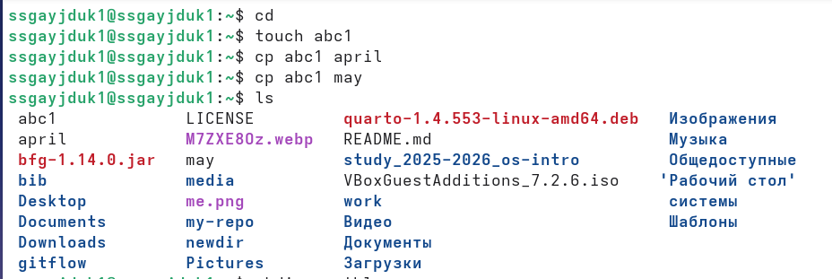

Figure 1: image1

## Копирование файлов

Скопируем файлы april и may в каталог monthly (рис. 2).

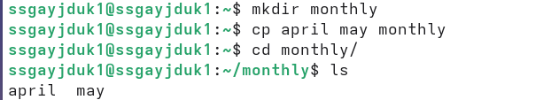

Figure 2: image2

Скопируем файл monthly/may в файл с именем june (рис. 3).

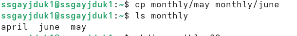

Figure 3: image3

## Копирование каталогов

Скопируем каталог monthly в каталог monthly.00 (рис. 4).

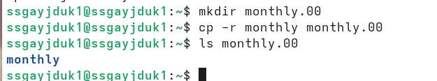

Figure 4: image4

Скопируем каталог monthly.00 в каталог /tmp (рис. 5).

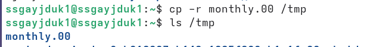

Figure 5: image5

## Изменение названия

Изменим название файла april на july в домашнем каталоге (рис. 6).

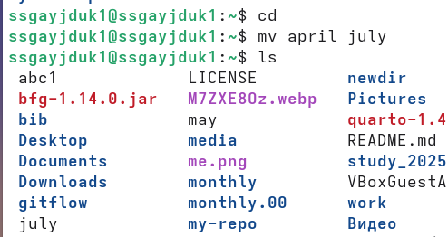

Figure 6: image6

## Перемещение файла

Переместим файл july в каталог monthly.00 (рис. 7).

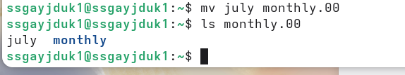

Figure 7: image7

## Изменение названия

Переименуем каталог monthly.00 в monthly.01 (рис. 8).

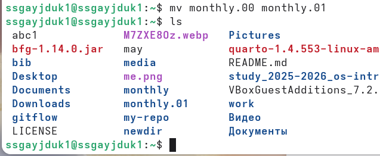

Figure 8: image8

## Перемещение каталогов

Переместим каталог monthly.01в каталог reports (рис. 9).

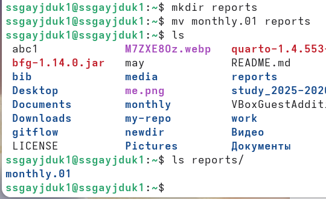

Figure 9: image9

## Изменение названия

Переименуем каталог reports/monthly.01 в reports/monthly (рис. 10).

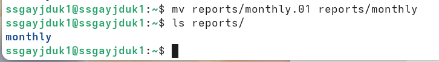

Figure 10: image10

## Создание файла

Создадим файл ~/may с правом выполнения для владельца (рис. 11).

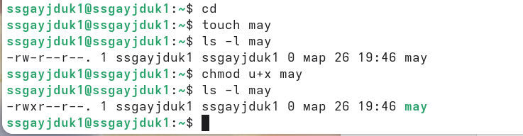

Figure 11: image11

## Права на выполнение

Лишим владельца файла ~/may права на выполнение (рис. 12).

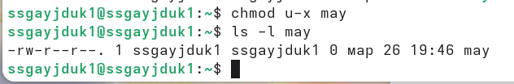

Figure 12: image12

## Создание каталогов

Создадим каталог monthly с запретом на чтение для членов группы и всех остальных пользователей (рис. 13).

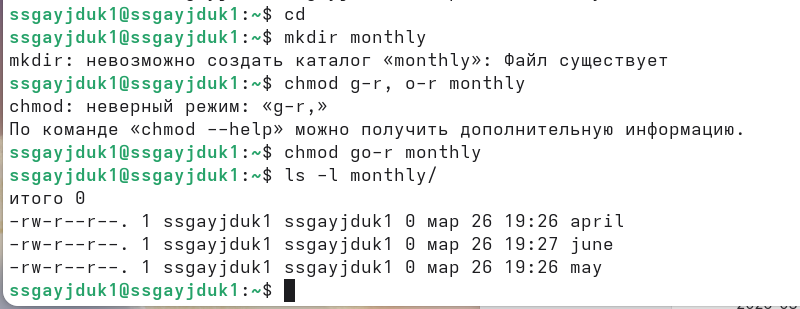

Figure 13: image13

## Создание файла

Создадим файл ~/abc1 с правом записи для членов группы (рис. 14).

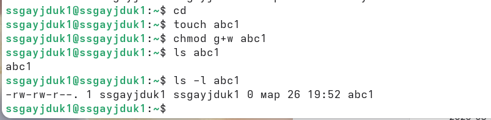

Figure 14: image14

## Копирование файлов

Скопируем файл /usr/include/sys/io.h в домашний каталог и назовите его equipment (рис. 15).

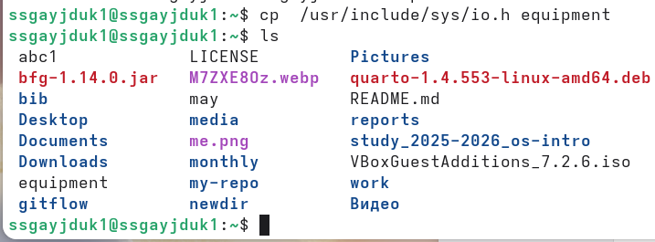

Figure 15: image15

## Перемещение файла

Переместим файл equipment в каталог ~/ski.plases (рис. 17).

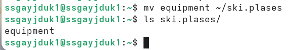

Figure 17: image17

## Изменение названия

Переименуем файл ~/ski.plases/equipment в ~/ski.plases/equiplist (рис. 18).

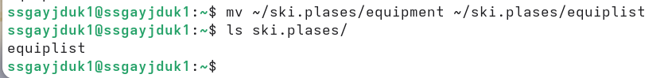

Figure 18: image18

## Создание и копирование

Создадим в домашнем каталоге файл abc1 и скопируйте его в каталог ~/ski.plases, назовите его equiplist2 (рис. 19).

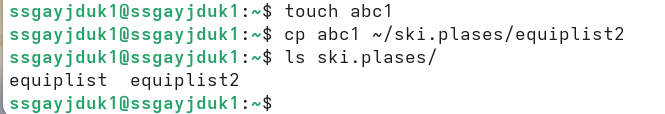

Figure 19: image19

## Перемещение файла

Переместим файлы ~/ski.plases/equiplist и equiplist2 в каталог ~/ski.plases/equipment (рис. 21, рис. 22).

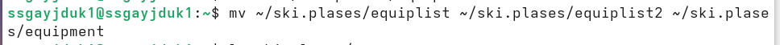

Figure 21: image21

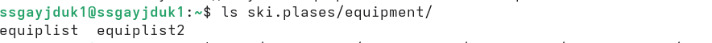

Figure 22: image22

## Перемещение и создание каталога

Создадим и переместим каталог ~/newdir в каталог ~/ski.plases и назовите его plans (рис. 23, рис. 24).

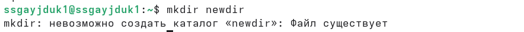

Figure 23: image23

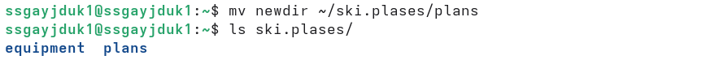

Figure 24: image24

## Права на выполнение

Определим опции команды chmod, необходимые для того, чтобы присвоить файлам (australia, play, my_os, feathers) выделенные права доступа, также создадим нужные файлы (рис. 25, рис. 26, рис. 27)

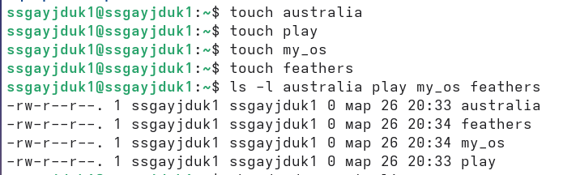

Figure 25: image25

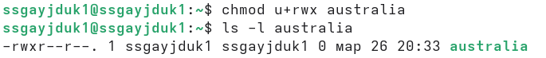

Figure 26: image26

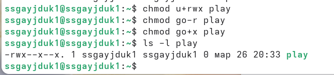

Figure 27: image27